# Ad hoc methods

2022-05-16

## Missing data mechanisms (recap)

## Assuming the missing data mechanism (MCAR)

The methods to deal with missing data, implicitly assume a missing data mechanism.

**MCAR**: the most strict assumption. In practice it is also easiest to deal with MCAR data.

1. Analyze the observed sample only (this will result in unbiased estimates).
2. Use an imputation method to boost the power the the amount of missing data is too large.

## Assuming the missing data mechanism (MAR)

**MAR**: less strict assumption. Most advanced missing data methods assume this mechanism (e.g. multiple imputation, FIML).

- Include variables in study that may explain the missing data, a MAR assumption may become more plausible (as compared to MNAR).
- These auxiliary variables may also help in dealing with the missing data.
- **Auxiliary variables**: variables related to the probability of missing data or to the variable with missing data.
  - Can be used as predictors in an imputation model or as covariates in a FIML model to improve estimations.

## Assuming the missing data mechanism (MNAR)

**MNAR**: least strict assumption.

- MNAR data are also referred to as non-ignorable, because these cannot be ignored without causing bias in results. MNAR data are more challenging to deal with.

## Ad hoc missing data methods

## Complete-case analysis

**Complete-case analysis (CCA)**: only the cases with observed data for all variables involved are used in the analysis.

- The most common and easy way to deal with missing data.
- The default method for many data analysis procedures.
- Assumes MCAR

**Parameter estimates**:

- Mean is unbiased for MCAR
- Regression weight/correlation unbiased for MCAR
- Standard errors are overestimated

## CCA

MCAR | regression

|  | estimate | std.error | p.value |
| --- | --- | --- | --- |
| Complete | 0.22 | 0.09 | 0.02 |
| MCAR | 0.24 | 0.17 | 0.16 |

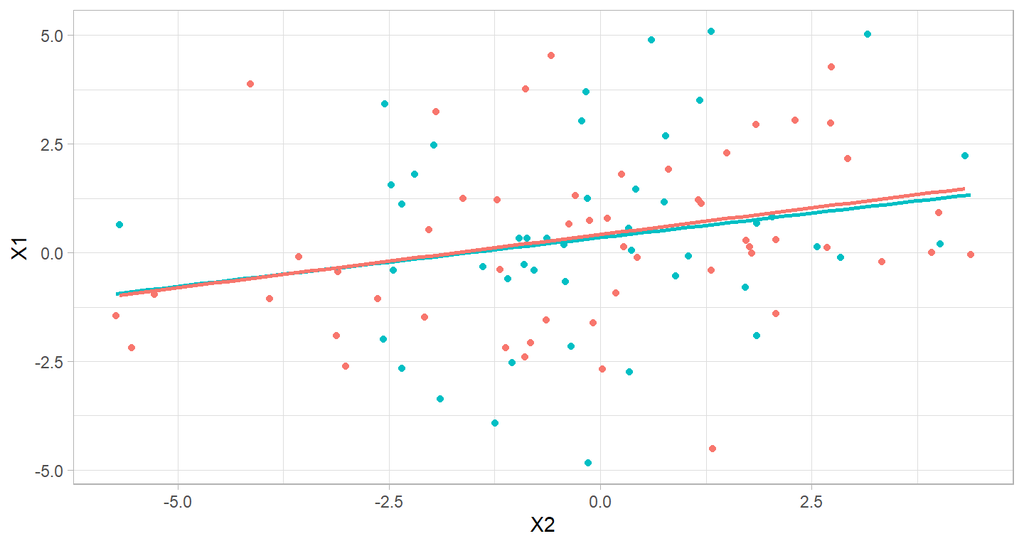

## CCA

MAR | regression

|  | estimate | std.error | p.value |
| --- | --- | --- | --- |
| Complete | 0.22 | 0.09 | 0.02 |
| MAR | 0.09 | 0.15 | 0.53 |

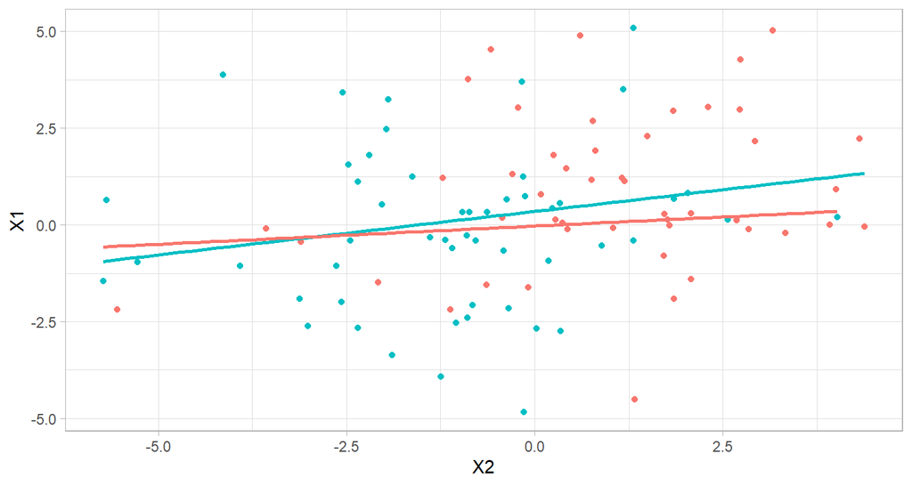

## Imputation

**Imputation:** replacing the missing with a value.

*Possible values to impute?*

- Mean
- Regression estimate
- Random value
- Previous observation (longitudinal study)
- Informed guess / estimate
- …

## Assumption of *single* imputation

Other examples:

- All missing values are average (i.e. mean imputation)
- People with missing data remain stable (i.e. LOCF)

## Example data

| Gender | n | Weight n | Weight mean | Weight sd | Performance n | Performance mean | Performance sd |
| --- | --- | --- | --- | --- | --- | --- | --- |
| Man | 81 | 73 | 86.009 | 9.660 | 73 | 7.998 | 3.539 |
| Woman | 61 | 50 | 75.782 | 8.478 | 52 | 9.782 | 3.238 |

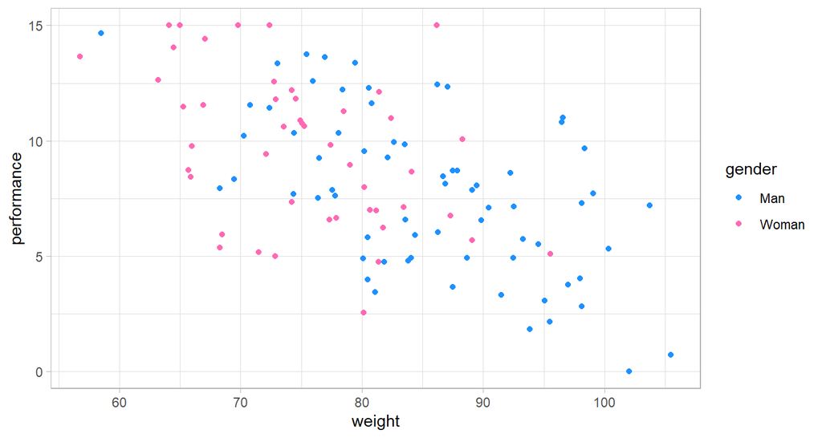

## Mean imputation

- Imputing the average value for all missing entries
- Very easy method

**Parameter estimates**:

- Mean is unbiased when MCAR
- Regression weight/correlation never unbiased
- Standard errors are underestimated

## Mean imputation

### Example

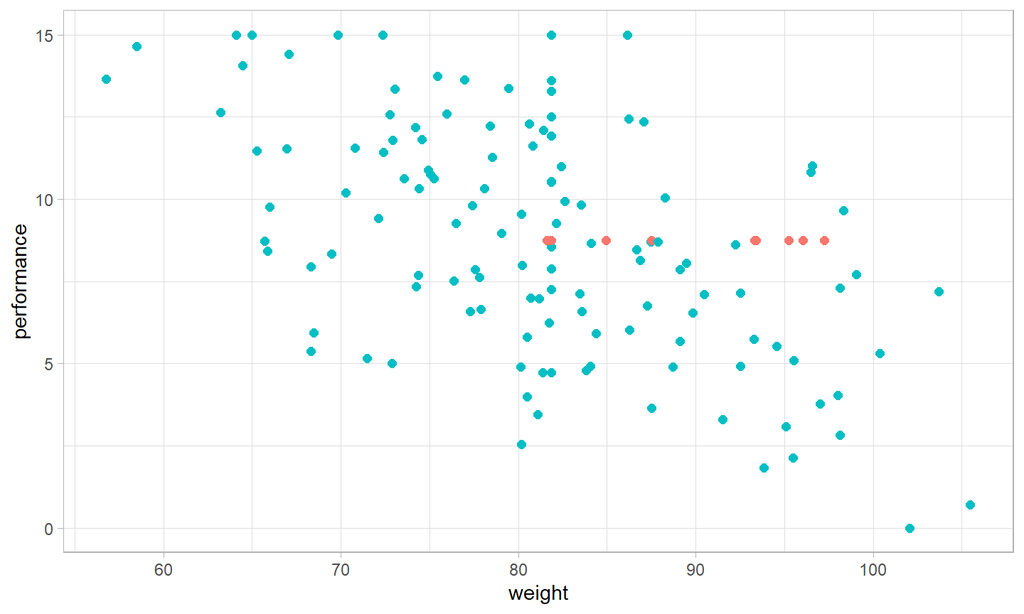

## Regression imputation

Conditional mean imputation, estimating the imputed value as a predicted value from a regression model: \(Y_{imp} = \beta_0 + \beta_1 * X\)

Parameter estimates:

- Mean is unbiased when MAR
- Regression weight is unbiased when MAR
- Correlation is never unbiased
- Standard errors are underestimated

## Regression imputation

### Example

Imputation from regression equation: \(Performance = \beta_0 + \beta_1 * weight + \beta_2 * gender\)

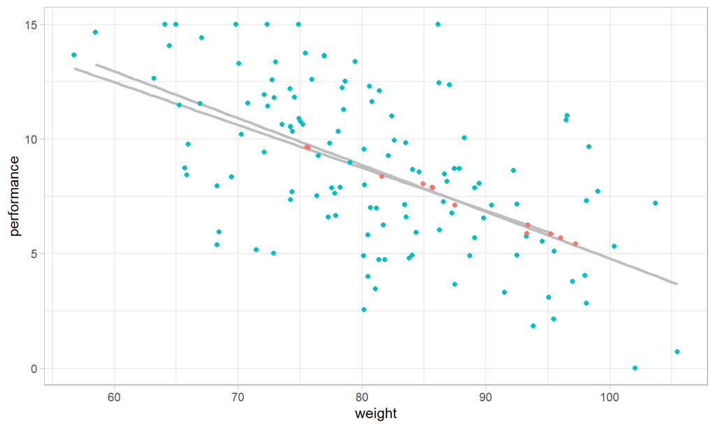

## Regression imputation + sampling error

Stochastic regressions: = regression imputation, with additional sampling error added to the predicted value:

- \(Y_{imp} = \beta_0 + \beta_1 * X + \epsilon\)

Sampling error is normally distributed.

Parameter estimates:

- Mean is unbiased when MAR
- Regression weight is unbiased when MAR
- Correlation is unbiased when MAR
- Standard errors are underestimated

*Imputation uncertainty is not taken into account*

## Regression imputation + residual error

### Example

Imputation from regression equation: \(Performance = \beta_0 + \beta_1 * weight + \beta_2 * gender + \epsilon\)

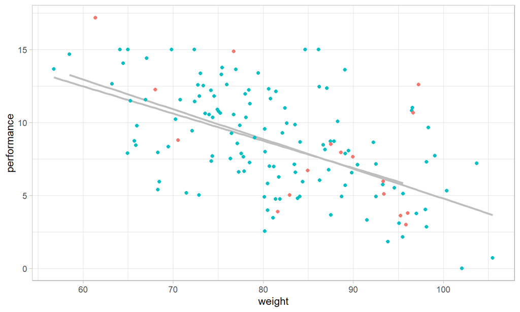

## Last observation carried forward

Ad hoc method for longitudinal data: use the previous observed value to impute the missing values.

Assumes that people that drop out of the study remain stable.

- Mean, regression coefficient and correlation is never unbiased.
- Standard errors are underestimated

## Example data

- A RCT for a weight loss intervention.
- Measurements at baseline, mid-treatment (3m), post-treatment (6m), and two follow-up moments (12m and 24m).
- Missing data occurs at the measurements after the baseline, due to study drop-out.

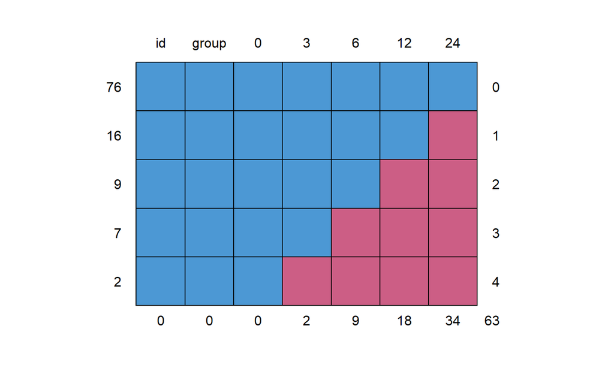

```
##    id group 0 3 6 12 24
## 76  1     1 1 1 1  1  1  0
## 16  1     1 1 1 1  1  0  1
## 9   1     1 1 1 1  0  0  2
## 7   1     1 1 1 0  0  0  3
## 2   1     1 1 0 0  0  0  4
##     0     0 0 2 9 18 34 63
```

## LOCF

### Example imputed

The trajectories over time, with LOCF imputations in red.

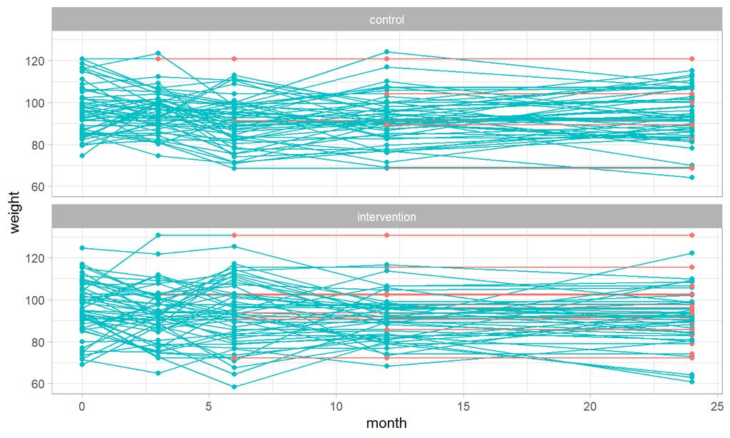

## LOCF

### Example imputed

Below only the cases with missing observations, separated by group.

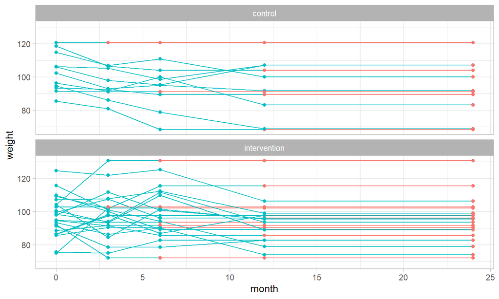